# Survey Methodology II Assignment

## Regression and machine learning models

### Multilevel models

As the data has a multilevel structure, that is, observations are organised in nested levels with each level representing a different unit of analysis, a multilevel or hierarchical model is the most appropriate model . Multilevel models can distinguish between both within-group variation (variation within the same higher-level unit) and between-group variation (variation between different higher-level units) which allows for the estimation of predictors within different levels of the hierarchy. The data utilized in this assignment contains two levels: the individuals level (the lower level) and the country level (the higher level). The country level variables: c*onstitutional_protections_against_discrimination, lgbt_policy_index, gender_marker_change, gdi* and *countrycode* are specified as the random effects in the model and all survey variables as fixed effect. This multilevel model will allow us to create a model with differing intercepts for the higher level variables and interpret the coefficients of the lower level variables free from any effect of the higher level variables.

#### Splitting data set and scaling numerical variables

```r
# Delete variables with too many categories
data_s<- full_data_red |>
 dplyr::select(-internetuse_index, -religion_denomination)


# Identify numeric columns
numeric_cols <- sapply(data_s, is.numeric)

# Scale only numeric columns
scaled_numeric <- scale(data_s[, numeric_cols])

# Combine scaled numeric columns with non-numeric columns
data <- cbind(scaled_numeric,data_s[!numeric_cols])

# Partition the data into a test and training data set
set.seed(123)
train_index <- createDataPartition(data_s$transgender_changecivildocuments, p = 0.8, list = FALSE)
train_data <- data_s[train_index, ]
test_data <- data_s[-train_index, ]

# Grouping the fixed effect variables
fixed_var <- data_s |>
  dplyr::select(-freedom_expresion_index,
         -constitutional_protections_against_discrimination,
         -lgbt_policy_index,
         -gender_marker_change,
         -gdi,
         -countrycode,
         -country,
         -transgender_changecivildocuments)

# Creating a list of ficed effect variables
fixed_var<- names(fixed_var)
```

#### Running multiple models with cross-validation

In the following chunk, multiple multilevel models are specified and run using the cv() function from the cv package

```r
train_data$countrycode <- as.factor(train_data$countrycode)


# Create different formulas to be included in the multilevel model
# Full model
formula <- as.formula(paste("transgender_changecivildocuments ~", paste(fixed_var, collapse = " + "), "+ (1|countrycode) + (1|gdi) + (1|freedom_expresion_index)+ (1|constitutional_protections_against_discrimination) + (1|lgbt_policy_index)+
(1|gender_marker_change) "))

#All fixed effect variables, only country code and gdi as random effect variables
formula_2 <- as.formula(paste("transgender_changecivildocuments ~", paste(fixed_var, collapse = " + "), "+ (1|countrycode) + (1|gdi)"))

#All fixed effect variables, only country code and freedom_expresion_index as random effect variables
formula_3 <- as.formula(paste("transgender_changecivildocuments ~", paste(fixed_var, collapse = " + "), "+ (1|countrycode) + (1|freedom_expresion_index)"))

#All fixed effect variables, only country code and constitutional_protections_against_discrimination as random effect variables
formula_4 <- as.formula(paste("transgender_changecivildocuments ~", paste(fixed_var, collapse = " + "), "+ (1|countrycode) + (1|constitutional_protections_against_discrimination)"))

#All fixed effect variables, only country code and lgbt_policy_index as random effect variables
formula_5 <- as.formula(paste("transgender_changecivildocuments ~", paste(fixed_var, collapse = " + "), "+ (1|countrycode) + (1|lgbt_policy_index) "))

#All fixed effect variables, only country code and gender_marker_chang as random effect variables
formula_6 <- as.formula(paste("transgender_changecivildocuments ~", paste(fixed_var, collapse = " + "), "+ (1|countrycode) +
(1|gender_marker_change) "))

#Specifying the models
model_1 <- glmmTMB(formula, data = train_data, family = binomial)
model_2 <- glmmTMB(formula, data = train_data, family = binomial(link = "probit"))
model_3 <- glmmTMB(formula, data = train_data, family = binomial(link = "cloglog"))
model_4 <- glmmTMB(formula_2, data = train_data, family = binomial)
model_5 <- glmmTMB(formula_3, data = train_data, family = binomial)
model_6 <- glmmTMB(formula_4, data = train_data, family = binomial)
model_7 <- glmmTMB(formula_5, data = train_data, family = binomial)
model_8 <- glmmTMB(formula_6, data = train_data, family = binomial)


#Combining the models in a 'modlist' object
model <- models(model_1,model_2, model_3, model_4, model_5, model_6, model_7, model_8)


#Running all models with cross validation
model_cv <-cv(
model,
data = train_data,
criterion = mse,
k = 3, #set higher
reps = 1,
level = 0.95,
ncores = 1)
```

#### Selecting the best model

```r
print(model_cv)
```

```
Model model.1:
3-Fold Cross Validation
cross-validation criterion = 0.1242789
bias-adjusted cross-validation criterion = 0.1195458
95% CI for bias-adjusted CV criterion = (0.1093857, 0.1297059)
full-sample criterion = 0.1019642

Model model.2:
3-Fold Cross Validation
cross-validation criterion = 0.123884
bias-adjusted cross-validation criterion = 0.1193917
95% CI for bias-adjusted CV criterion = (0.1094393, 0.1293442)
full-sample criterion = 0.1030136

Model model.3:
3-Fold Cross Validation
cross-validation criterion = 0.1244223
bias-adjusted cross-validation criterion = 0.1195697
95% CI for bias-adjusted CV criterion = (0.1094217, 0.1297177)
full-sample criterion = 0.1026716

Model model.4:
3-Fold Cross Validation
cross-validation criterion = 0.1240311
bias-adjusted cross-validation criterion = 0.119414
95% CI for bias-adjusted CV criterion = (0.1092624, 0.1295657)
full-sample criterion = 0.1018999

Model model.5:
3-Fold Cross Validation
cross-validation criterion = 0.1240301
bias-adjusted cross-validation criterion = 0.1193807
95% CI for bias-adjusted CV criterion = (0.1092329, 0.1295284)
full-sample criterion = 0.1019316

Model model.6:
3-Fold Cross Validation
cross-validation criterion = 0.1239585
bias-adjusted cross-validation criterion = 0.1193512
95% CI for bias-adjusted CV criterion = (0.109203, 0.1294994)
full-sample criterion = 0.1019048

Model model.7:
3-Fold Cross Validation
cross-validation criterion = 0.124178
bias-adjusted cross-validation criterion = 0.1194306
95% CI for bias-adjusted CV criterion = (0.1092656, 0.1295957)
full-sample criterion = 0.1019048

Model model.8:
3-Fold Cross Validation
cross-validation criterion = 0.1238941
bias-adjusted cross-validation criterion = 0.1193035
95% CI for bias-adjusted CV criterion = (0.1091553, 0.1294517)
full-sample criterion = 0.1019688
```

#### Interpretation of coefficients

The variance and the standard deviation of the random effects signify the differences and the standardized differences among the units of the random effect variable respectively. As the all random effect variables are measured in different scales only the standard deviations are interpreted. The variables *countrycode, freedom_expresion_index* and *gender_marker_change* show considerable high standard deviations indicating high variability in intercepts across different levels of this variable. In other words, we can conclude that the values or levels of these variables differ significantly from one another.

Note that all coefficients are interpreted holding all other variables constant and only the statistically significant variables are interpreted. When log-odds are positive, they signify a higher likelihood of voting ‘no’

1. **gender2:** For females, the log-odds of them voting ‘no’ for transgender individuals to change their civil documents have lower log-odds (-0.35) compared to males.
2. **actsagainstdiscrim_sharedcontent2**: For individuals who have not shared content against discrimination, the log-odds of them voting ‘no’ for transgender individuals to change their civil documents are lower (-0.90) compared to those who have.
3. **officialdocuments_includethirdgend2**: Individuals who do not believe official documents should include a third gender have a much higher log-odds (3.13) of voting ‘no’ for transgender individuals to change their civil documents compared to those who do believe official documents should include a third gender.
4. **contact_transgendertranssexual2**: Individuals who have not had contact with transgender or transsexual individuals have higher log-odds (0.64 ) of voting ‘no’ for transgender individuals to change their civil documents compared to those who have had such contact.
5. **contact_transgendertranssexual3**: Individuals who have voted ‘don´t know’ to the the item if they ahve hadc contact with transgender or transsexual individuals have even higher log-odds (1.83) of voting ‘no’ for transgender individuals to change their civil documents compared to those who have had such contact.
6. **colleagues_homosexualbisexual3**: Individuals who have voted ‘totally comfortable’ on the item asking if they are comfortable with having homosexual or bisexual colleagues at work have lower log-odds (-0.77) of voting ‘no’ for transgender individuals to change their civil documents compared to those who voted ‘totally uncomfortable’.
7. **colleagues_transgender4**: Individuals who have voted that they are indifferent to having transgender colleagues at work have significantly lower log-odds (-3.40) of voting ‘no’ for transgender individuals to change their civil documents compared to those who have voted they are totally uncomfortable.
8. **loverelchild_personwsamesexaschild4**: Individuals who vote ‘indifferent’ to the statement if they would be comfortable with their child having a same-sex parter significantly have lower log-odds ( -2.88 ) of voting ‘no’ for transgender individuals to change their civil documents compared to those who vote ‘totally comfortable’.
9. **showaffectionpublic_twowomen**: Individuals who agree that they are comfortable with two women showing affection in public have lower log-odds ( -0.30 ) of voting ‘no’ for transgender individuals to change their civil documents compared to those who are uncomfortable.
10. **lgbstatements_samerightsashetero**: Individuals with higher disgreement with regards to the statement that LGBTQ+ individuals should have the same rights as heterosexual individuals have higher log-odds ( 0.30) of voting ‘no’ for transgender individuals to change their civil documents.
11. **schoolinformdiv_beingintersex**: Individuals with higher disagreement on the item if schools should inform about being intersex have higher log-odds (0.23) of voting ‘no’ for transgender individuals to change their civil documents.
12. **discrim_sexualorientation**: Individuals who are more leaning towards not believing discrimination based on sexual orientation happens in their country have higher log-odds (0.24) of voting ‘no’ for transgender individuals to change their civil documents.

In other words, respondents who are **less** likely to vote ‘no’ for transgender individuals to change their civil documents are:

- women compared to men,
- individuals who have not shared content against discrimination compared to those who have,
- Individuals who have voted ‘totally comfortable’ on the item asking if they are comfortable with having homosexual or bisexual colleagues compared to those who are totally uncomfortable,
- Individuals who have voted that they are indifferent to having transgender colleagues compared to compared to those who have voted they are totally uncomfortable,
- Individuals who vote ‘indifferent’ to the statement if they would be comfortable with their child having a same-sex partner compared to those who vote ‘totally comfortable’,
- Individuals who agree that they are comfortable with two women showing affection in public compared to those who are uncomfortable.

People who are **more** likely to vote ‘no’ for transgender individuals to change their civil documents are:

- Individuals who do not believe official documents should include a third gender compared to those who do believe official documents should include a third gender,
- Individuals who have not had contact with transgender or transsexual individuals compared to to those who have had such contact,
- Individuals with higher disagreement with regards to the statement that LGBTQ+ individuals should have the same rights as heterosexual individuals,
- Individuals with higher disagreement on the item if schools should inform about being intersex,
- Individuals who are more leaning towards not believing discrimination based on sexual orientation happens in their country.

```r
summary(model_1)
```

```
 Family: binomial  ( logit )
Formula:
transgender_changecivildocuments ~ gender + actsagainstdiscrim_sharedcontent +
    actsagainstdiscrim_publiclydefended + actsagainstdiscrim_joinedassociationcampaign +
    actsagainstdiscrim_publiclyraisedissue + officialdocuments_includethirdgend +
    contact_transgendertranssexual + colleagues_homosexualbisexual +
    colleagues_transgender + colleagues_intersex + loverelchild_personwsamesexaschild +
    loverelchild_transgender + loverelchild_intersex + maritalstatus +
    ageedu_recode5cat + electpol_woman + electpol_intersex +
    phoneavailable_summarized + myvoicecounts_country + censusinfo_sexualorientation +
    lgbstatements_samerightsashetero + schoolinformdiv_beingintersex +
    showaffectionpublic_twowomen + discrim_sexualorientation +
    discrim_gender + discrim_beingintersex + divworkprom_sexualorientation +
    leftrightplacement + ageexact + (1 | countrycode) + (1 |
    gdi) + (1 | freedom_expresion_index) + (1 | constitutional_protections_against_discrimination) +
    (1 | lgbt_policy_index) + (1 | gender_marker_change)
Data: train_data

     AIC      BIC   logLik deviance df.resid
  1460.2   1827.4   -664.1   1328.2     1859

Random effects:

Conditional model:
 Groups                                            Name        Variance
 countrycode                                       (Intercept) 3.677e-01
 gdi                                               (Intercept) 7.784e-10
 freedom_expresion_index                           (Intercept) 5.883e-02
 constitutional_protections_against_discrimination (Intercept) 1.751e-11
 lgbt_policy_index                                 (Intercept) 1.624e-07
 gender_marker_change                              (Intercept) 1.650e-01
 Std.Dev.
 6.064e-01
 2.790e-05
 2.425e-01
 4.185e-06
 4.030e-04
 4.062e-01
Number of obs: 1925, groups:
countrycode, 28; gdi, 23; freedom_expresion_index, 25; constitutional_protections_against_discrimination, 2; lgbt_policy_index, 26; gender_marker_change, 6
```

[output cut: 111 more lines]

```
electpol_intersex                             0.277734
phoneavailable_summarized                     0.068277 .
myvoicecounts_country                         0.917810
censusinfo_sexualorientation                  0.358381
lgbstatements_samerightsashetero              0.000386 ***
schoolinformdiv_beingintersex                 0.004569 **
showaffectionpublic_twowomen                  0.000902 ***
discrim_sexualorientation                     0.015041 *
discrim_gender                                0.161464
discrim_beingintersex                         0.503875
divworkprom_sexualorientation                 0.222255
leftrightplacement                            0.752715
ageexact                                      0.471274
---
Signif. codes:  0 '***' 0.001 '**' 0.01 '*' 0.05 '.' 0.1 ' ' 1
```

### Machine learning models

Three machine learning algorithms: random forest, K-Nearest Neighbour and Recursive Partitioning and Regression Trees are utilized to predict the target variable *transgender_changecivildocuments.*

#### Splitting the data set

```r
# Delete variables with too many categories
data_m<- data

levels(data_m$transgender_changecivildocuments)

# Rename the levels
levels(data_m$transgender_changecivildocuments) <- c("yes", "no")

# Split the data into test and train data
set.seed(123)
train_index <- createDataPartition(data_m$transgender_changecivildocuments, p = 0.8, list = FALSE)
train_data <- data_m[train_index, ]
test_data <- data_m[-train_index, ]
```

#### The control function

```r
#Specifying the control function
ctrl <- trainControl(method = "repeatedcv",
                     number = 10,
                     classProbs = T,
                     verboseIter = T)
```

#### Random Forest

```r
# Define a grid for the hyper-parameters
param_grid = expand.grid(gamma = seq(0, 1, 0.1), lambda = seq(0.1, 0.9, 0.1))

# Specify mtry
mtry <- sqrt(ncol(train_data))
# Specify the tunegrid using mtry
tunegrid <- expand.grid(.mtry=mtry)

set.seed(123)
# Run the random forest model using the train() function from the Caret package
RfFit <- train(transgender_changecivildocuments ~ .,
                method ="rf",
                data = train_data,
                preProcess = c("center", "scale"),
                tuneGrid=tunegrid,
                metric="Accuracy",
                trControl = ctrl)
```

#### k-Nearest Neighbour

```r
# Run the k_Nearest Neighbour model using the train() function from the Caret package
set.seed(123)
knnFit <- train(transgender_changecivildocuments ~ .,
                method ="knn",
                data = train_data,
                preProcess = c("center", "scale"),
                metric="Accuracy",
                trControl = ctrl)
```

#### Recursive Partitioning and Regression Trees

```r
# Run the Recursive Partitioning and Regression Trees model using the train() function from the Caret package

set.seed(123)
rpartFit <- train(transgender_changecivildocuments ~ .,
                method ="rpart", #name of the model
                data = train_data,
                preProcess = c("center", "scale"),
                metric="Accuracy",
                trControl = ctrl)
```

### Performance analysis

As both the accuracy and Kappa is highest for the Random Forest model, this model will be selected for the prediction.

```r
# Resample results of accuracy metrics models
resample_results <- resamples(list(RF = RfFit, KNN = knnFit, RPART = rpartFit ))

# Show the accuracy metrics
summary(resample_results)
```

```
Call:
summary.resamples(object = resample_results)

Models: RF, KNN, RPART
Number of resamples: 10

Accuracy
           Min.   1st Qu.    Median      Mean   3rd Qu.      Max. NA's
RF    0.7875648 0.8237460 0.8385417 0.8332433 0.8469411 0.8756477    0
KNN   0.7253886 0.7464176 0.7702198 0.7755654 0.8080203 0.8341969    0
RPART 0.7927461 0.8039023 0.8103951 0.8197340 0.8329016 0.8593750    0

Kappa
           Min.   1st Qu.    Median      Mean   3rd Qu.      Max. NA's
RF    0.5481642 0.6283831 0.6550215 0.6461590 0.6785356 0.7349205    0
KNN   0.4185095 0.4603206 0.5095108 0.5225588 0.5924336 0.6496880    0
RPART 0.5697247 0.5932523 0.6097764 0.6260746 0.6536255 0.7103911    0
```

```r
dev.off()
```

```r
bwplot(resample_results , metric = c("Kappa","Accuracy"))
```

[output not shown]

### Prediction and interpretation based on the best model: Random Forest

#### Prediction

In the chunk below, predictions are made using the best model, based on data in the testing set and are consequently compared with the actual values from the test set to compute the final accuracy metrics and the confusion matrix. Hereafter, the predicted values are plotted against the actual values.

```r
predictions <- predict(RfFit, newdata = test_data)

# Create confusion matrix
confusionMatrix(predictions, test_data$transgender_changecivildocuments)$table
```

```
          Reference
Prediction yes  no
       yes 259  65
       no   30 127
```

```r
# Compute final Accuracy and Kappa
confusionMatrix(predictions, test_data$transgender_changecivildocuments)$overall[1:2]
```

```
 Accuracy     Kappa
0.8024948 0.5752503
```

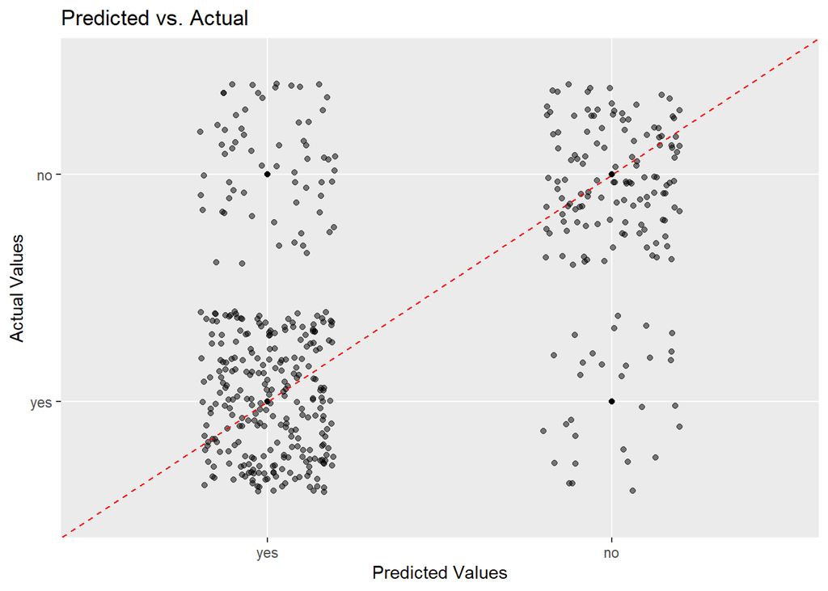

```r
#Plot the predicted vs the actual values
ggplot(data = test_data, aes(x = predictions, y = transgender_changecivildocuments)) +
  geom_jitter(width = 0.2, alpha = 0.5)+
  geom_point() +
  geom_abline(intercept = 0, slope = 1, linetype = "dashed", color = "red") +
  labs(title = "Predicted vs. Actual",
       x = "Predicted Values",
       y = "Actual Values")
```

### Interpretation

#### Variable importance

The plot below shows the 10 most important variables of the model.

```r
RfFit_imp <- varImp(RfFit, scale = F)
RfFit_imp
```

```
rf variable importance

  only 20 most important variables shown (out of 118)

                                    Overall
officialdocuments_includethirdgend2  112.25
lgbstatements_samerightsashetero      45.96
schoolinformdiv_beingintersex         33.51
lgbt_policy_index                     33.08
showaffectionpublic_twowomen          31.78
ageexact                              27.34
freedom_expresion_index               24.91
colleagues_homosexualbisexual3        21.85
colleagues_transgender3               21.00
gdi                                   20.81
electpol_intersex                     20.44
leftrightplacement                    19.36
divworkprom_sexualorientation         16.79
gender_marker_change                  15.27
colleagues_intersex3                  14.78
loverelchild_transgender3             14.58
loverelchild_personwsamesexaschild3   14.41
censusinfo_sexualorientation          14.18
myvoicecounts_country                 14.07
loverelchild_intersex3                13.94
```

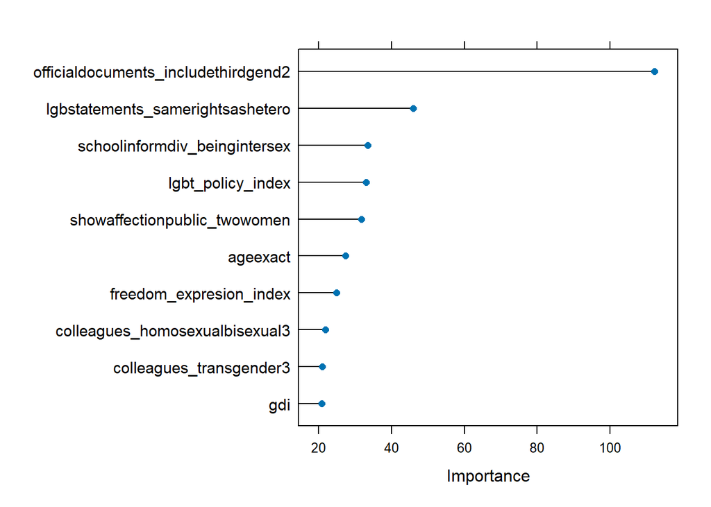

```r
plot(RfFit_imp, scales = list(y = list(cex = .95)), top=10)
```